# Tooth Growth Analysis

Helen

24 October 2018

## Overview

This report analyses the ToothGrowth data from the R datasets. The data is explored, summarised and compared. A sample of the dataset is shown below.

```r
head(ToothGrowth)
```

```
##    len supp dose
## 1  4.2   VC  0.5
## 2 11.5   VC  0.5
## 3  7.3   VC  0.5
## 4  5.8   VC  0.5
## 5  6.4   VC  0.5
## 6 10.0   VC  0.5
```

## Exploratory analysis

The data has three variables: “len”, “supp” and “dose”. The results split by supp and dose are shown in the graph below.

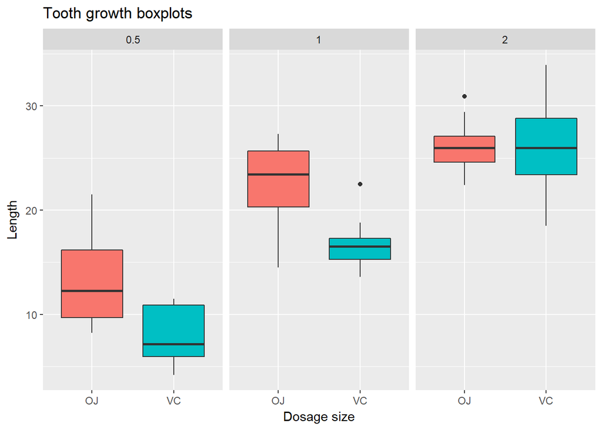

```r
g1 <- ggplot(ToothGrowth, aes(x = supp, y = len, fill = supp)) + geom_boxplot() + facet_grid(. ~ dose) + ggtitle("Tooth growth boxplots") + xlab("Dosage size") + ylab("Length") + guides(fill = "none")
g1
```

The graph shows that for both supplements the length tends to increase as dose increases. The OJ supplement appears to result in greater length than VC for doses 0.5 and 1, but the supplements appear to result in similar lengths at doses of 2.

The graph also shows that the resulting lengths were slightly more variable for the OJ supplement at doses 0.5 and 1, though a lot less variable than VC at dose 2.

It remains to be seen whether these differences are significant.

There is some overlap in the lengths resulting from different doses, particularly from the OJ supplement. This can be seen in the graph below.

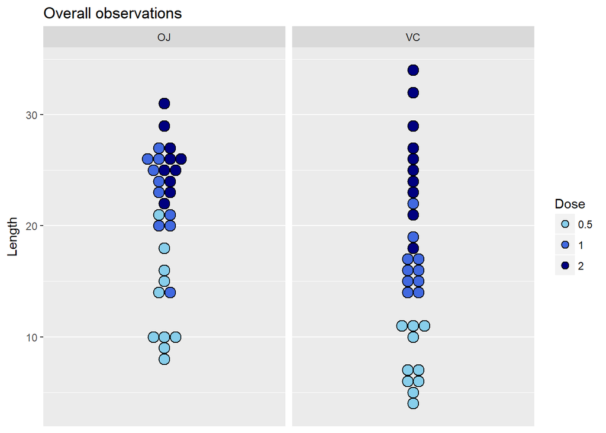

```r
g3 <- ggplot(ToothGrowth, aes(y = len, x = 1, fill = factor(dose))) + geom_dotplot(binwidth= 1, method = "histodot", binaxis = "y", stackgroups = TRUE, stackdir = "center") + facet_grid(. ~ supp) + ggtitle("Overall observations") + xlab("Supplement") + ylab("Length") + scale_fill_manual(values = c("skyblue", "royalblue", "navy"), name = "Dose") + scale_x_continuous(NULL, breaks = NULL)
g3
```

The graph also shows that a greater range of lengths resulted from the VC supplement. It can be seen that each dose and supplement combination has 10 observations.

## Data summary

The data consists of 60 observations of odontoblast length, subdivided by supplement and dose. The table below summarises the data and its main features.

```r
tg <- tbl_df(ToothGrowth)
tg <- group_by(tg, dose, supp)
summarise(tg, n(), min(len), max(len), mean(len), sd(len))
```

```
## # A tibble: 6 x 7
## # Groups:   dose [?]
##    dose supp  `n()` `min(len)` `max(len)` `mean(len)` `sd(len)`
##   <dbl> <fct> <int>      <dbl>      <dbl>       <dbl>     <dbl>
## 1 0.500 OJ       10       8.20       21.5       13.2       4.46
## 2 0.500 VC       10       4.20       11.5        7.98      2.75
## 3 1.00  OJ       10      14.5        27.3       22.7       3.91
## 4 1.00  VC       10      13.6        22.5       16.8       2.52
## 5 2.00  OJ       10      22.4        30.9       26.1       2.66
## 6 2.00  VC       10      18.5        33.9       26.1       4.80
```

## Comparing tooth growth by supp and dose

First, this report considers the two supplements separately, and tests whether the differences in odontoblast length seen due to the different dosage levels of each supplement are significant. For example, is the difference is length resulting from receiving a dosage of 0.5 OJ significantly different to that resulting from a dosage of 1 OJ?

### OJ

#### *Is the additional length seen at dosage 1 significantly higher than at dosage 0.5?*

**Null hypothesis:** The mean of OJ’s dosage 1 is the same as the mean of OJ’s dosage 0.5.  
**Alternative hypothesis:** The mean of OJ’s dosage 1 is greater than the mean of OJ’s dosage 0.5.

The data are not paired, so an independent t-test must be used. A one sided test is used because the hypothesis is that a larger dose will result in more growth.

```r
OJ0 <- filter(ToothGrowth, supp == "OJ", dose == 0.5)
OJ1 <- filter(ToothGrowth, supp == "OJ", dose == 1)

t.test(OJ0[, 1], OJ1[, 1], alt = "less", mu = 0, paired = FALSE, var.equal = FALSE)
```

```
##
##  Welch Two Sample t-test
##
## data:  OJ0[, 1] and OJ1[, 1]
## t = -5.0486, df = 17.698, p-value = 4.392e-05
## alternative hypothesis: true difference in means is less than 0
## 95 percent confidence interval:
##       -Inf -6.214316
## sample estimates:
## mean of x mean of y
##     13.23     22.70
```

Manual calculation of t statistic:

```r
var <- ((nrow(OJ0)-1)*var(OJ0[, 1])+(nrow(OJ1)-1)*var(OJ1[, 1]))/(nrow(OJ0)+nrow(OJ1)-2)

t <- (mean(OJ0[, 1]) - mean(OJ1[, 1])) / (sqrt(var) * (1/10 + 1/10)^0.5)
t
```

```
## [1] -5.048635
```

Manual calculation of confidence interval of t statistic:

```r
ci <- mean(OJ0[, 1]) - mean(OJ1[, 1]) + 1 * qt(0.95, 18) * sqrt(var) * (1/10 + 1/10)^0.5
ci
```

```
## [1] -6.217322
```

Manual calculation of p value:

```r
pOJ01 <- pt(t, df = 18)
pOJ01
```

```
## [1] 4.17878e-05
```

The manual calculations agree with the t.test calculations.

The results show that it is 95% certain that the mean of OJ dose 0.5 minus the mean of OJ dose 1 is -6.21 or less. This does not include zero so the means are statistically significantly different. The p-value for the test is 4.2x10<sup>-5</sup> which means the result is significant at the 5% level.

#### *Is the additional length seen at dosage 2 significantly higher than at dosage 1?*

**Null hypothesis:** The mean of OJ’s dosage 2 is the same as the mean of OJ’s dosage 1.  
**Alternative hypothesis:** The mean of OJ’s dosage 2 is greater than the mean of OJ’s dosage 1.

```r
OJ2 <- filter(ToothGrowth, supp == "OJ", dose == 2)
t.test(OJ1[, 1], OJ2[, 1], alt = "less", paired = FALSE, var.equal = FALSE)
```

```
##
##  Welch Two Sample t-test
##
## data:  OJ1[, 1] and OJ2[, 1]
## t = -2.2478, df = 15.842, p-value = 0.0196
## alternative hypothesis: true difference in means is less than 0
## 95 percent confidence interval:
##        -Inf -0.7486236
## sample estimates:
## mean of x mean of y
##     22.70     26.06
```

Manual checks:

```r
var <- (((nrow(OJ1)-1)*var(OJ1[, 1]))+(nrow(OJ2)-1)*var(OJ2[, 1]))/(nrow(OJ1)+nrow(OJ2)-2)
t <- (mean(OJ1[, 1]) - mean(OJ2[, 1])) / (sqrt(var)*(1/10+1/10)^0.5)
t
```

```
## [1] -2.247761
```

```r
ci <- (mean(OJ1[, 1]) - mean(OJ2[, 1])) + 1 * qt(0.95, 18) * (sqrt(var)*(1/10+1/10)^0.5)
ci
```

```
## [1] -0.7678858
```

```r
vOJ1 <- var(OJ1[, 1])
vOJ2 <- var(OJ2[, 1])
nOJ1 <- nrow(OJ1)
nOJ2 <- nrow(OJ2)
df <- ((vOJ1/nOJ1 + vOJ2/nOJ2)^2)/((vOJ1/nOJ1)^2/(nOJ1-1) + (vOJ2/nOJ2)^2/(nOJ2-1))
df
```

```
## [1] 15.84238
```

```r
pOJ12 <- pt(t, df = df)
pOJ12
```

```
## [1] 0.01959757
```

The manual checks agree with t.test. Again the difference is significant at the 5% level.

### VC

#### *Is the additional length seen at dosage 1 significantly higher than at dosage 0.5?*

**Null hypothesis:** The mean of VC’s dosage 1 is the same as the mean of VC’s dosage 0.5.  
**Alternative hypothesis:** The mean of VC’s dosage 1 is greater than the mean of VC’s dosage 0.5.

```r
VC0 <- filter(ToothGrowth, supp == "VC", dose == 0.5)
VC1 <- filter(ToothGrowth, supp == "VC", dose == 1)
vVC0 <- var(VC0[, 1])
vVC1 <- var(VC1[, 1])
nVC0 <- nrow(VC0)
nVC1 <- nrow(VC1)
vVC01 <- ((nVC0-1)*vVC0 + (nVC1-1)*vVC1)/(nVC0+nVC1-2)
t.test(VC0[, 1], VC1[, 1], "less", paired = FALSE, var.equal = FALSE, conf.level = 0.95)
```

```
##
##  Welch Two Sample t-test
##
## data:  VC0[, 1] and VC1[, 1]
## t = -7.4634, df = 17.862, p-value = 3.406e-07
## alternative hypothesis: true difference in means is less than 0
## 95 percent confidence interval:
##       -Inf -6.746867
## sample estimates:
## mean of x mean of y
##      7.98     16.77
```

Manual check:

```r
tVC01 <- (mean(VC0[, 1]) - mean(VC1[, 1]))/(sqrt(vVC01)*(1/nVC0 + 1/nVC1)^0.5)
tVC01
```

```
## [1] -7.46343
```

```r
dfVC01 <- (vVC0/nVC0 + vVC1/nVC1)^2/((vVC0/nVC0)^2/(nVC0-1) + (vVC1/nVC1)^2/(nVC1 - 1))
ciVC01 <- mean(VC0[, 1]) - mean(VC1[, 1]) + 1 * qt(0.95, dfVC01) * sqrt(vVC01) * (1/nVC0 + 1/nVC1)^0.5
ciVC01
```

```
## [1] -6.746867
```

```r
pVC01 <- pt(tVC01, dfVC01)
pVC01
```

```
## [1] 3.405509e-07
```

#### *Is the additional length seen at dosage 2 significantly higher than at dosage 1?*

**Null hypothesis:** The mean of VC’s dosage 2 is the same as the mean of VC’s dosage 1.  
**Alternative hypothesis:** The mean of VC’s dosage 2 is greater than the mean of VC’s dosage 1.

```r
VC2 <- filter(ToothGrowth, supp == "VC", dose == 2)
nVC2 <- nrow(VC2)
vVC2 <- var(VC2[, 1])
vVC12 <- ((nVC1-1)* vVC1 + (nVC2-1)*vVC2)/(nVC1+nVC2-2)
t.test(VC1[, 1], VC2[, 1], alt="less", paired = FALSE, var.equal = FALSE, conf.level = 0.95)
```

```
##
##  Welch Two Sample t-test
##
## data:  VC1[, 1] and VC2[, 1]
## t = -5.4698, df = 13.6, p-value = 4.578e-05
## alternative hypothesis: true difference in means is less than 0
## 95 percent confidence interval:
##       -Inf -6.346525
## sample estimates:
## mean of x mean of y
##     16.77     26.14
```

Manual checks:

```r
tVC12 <- (mean(VC1[, 1]) - mean(VC2[, 1])) / (sqrt(vVC12) * sqrt(1/nVC1 + 1/nVC2))
tVC12
```

```
## [1] -5.469814
```

```r
dfVC12 <- (vVC1/nVC1 + vVC2/nVC2)^2/((vVC1/nVC1)^2/(nVC1-1) + (vVC2/nVC2)^2/(nVC2-1))
dfVC12
```

```
## [1] 13.59996
```

```r
ciVC12 <- mean(VC1[, 1]) - mean(VC2[, 1]) + 1 * qt(0.95, dfVC12) * sqrt(vVC12* (1/nVC1 + 1/nVC2))
ciVC12
```

```
## [1] -6.346525
```

```r
pVC12 <- pt(tVC12, dfVC12)
pVC12
```

```
## [1] 4.577802e-05
```

The alternative hypothesis has been accepted at the 5% level for all four tests. A multiple hypothesis correction is required which is conducted further on in this report.

### OJ vs VC

#### *Are there significant differences between the lengths seen at dose 0.5 due to the different supplements used?*

**Null hypothesis:** The mean length seen at dose 0.5 is the same for OJ and VC.  
**Alternative hypothesis:** The mean length seen at dose 0.5 is different for OJ and VC.

Here a two sided test is used because before collecting the data there was no indication as to which supplement would work best.

```r
vOJ0 <- var(OJ0[, 1])
nOJ0 <- nrow(OJ0)
vOJVC0 <- ((nOJ0 -1)*vOJ0 + (nVC0 - 1) * vVC0)/(nOJ0 + nVC0 -2)
t.test(OJ0[, 1],VC0[, 1], alt = "two.sided", var.equal = FALSE, conf.level = 0.95)
```

```
##
##  Welch Two Sample t-test
##
## data:  OJ0[, 1] and VC0[, 1]
## t = 3.1697, df = 14.969, p-value = 0.006359
## alternative hypothesis: true difference in means is not equal to 0
## 95 percent confidence interval:
##  1.719057 8.780943
## sample estimates:
## mean of x mean of y
##     13.23      7.98
```

Manual checks:

```r
t0 <- (mean(OJ0[, 1]) - mean(VC0[, 1])) / sqrt(vOJVC0 * (1/nOJ0 + 1/nVC0))
t0
```

```
## [1] 3.169733
```

```r
df0 <- (vOJ0/nOJ0 + vVC0/nVC0)^2 / ((vOJ0/nOJ0)^2/(nOJ0 -1) + (vVC0/nVC0)^2/(nVC0 -1))
df0
```

```
## [1] 14.96875
```

```r
ci0 <- (mean(OJ0[, 1])- mean(VC0[, 1])) + c(-1,1) * qt(0.975, df0) * sqrt(vOJVC0 * (1/nOJ0 + 1/nVC0))
ci0
```

```
## [1] 1.719057 8.780943
```

```r
p0 <- 2*(pt(-abs(t0), df0))
p0
```

```
## [1] 0.006358607
```

#### *Are there significant differences between the lengths seen at dose 1 due to the different supplements used?*

**Null hypothesis:** The mean length seen at dose 1 is the same for OJ and VC.  
**Alternative hypothesis:** The mean length seen at dose 1 is different for OJ and VC.

```r
t.test(OJ1[, 1], VC1[, 1], alt = "two.sided", var.equal = FALSE, conf.level = 0.95)
```

```
##
##  Welch Two Sample t-test
##
## data:  OJ1[, 1] and VC1[, 1]
## t = 4.0328, df = 15.358, p-value = 0.001038
## alternative hypothesis: true difference in means is not equal to 0
## 95 percent confidence interval:
##  2.802148 9.057852
## sample estimates:
## mean of x mean of y
##     22.70     16.77
```

Manual checks:

```r
vOJVC1 <- ((nOJ1 -1) * vOJ1 + (nVC1 -1) * vVC1)/(nOJ1 + nVC1 -2)
t1 <- (mean(OJ1[, 1]) - mean(VC1[, 1])) / sqrt(vOJVC1 * (1/nOJ1 + 1/nVC1))
t1
```

```
## [1] 4.03277
```

```r
df1 <- (vOJ1/nOJ1 + vVC1/nVC1)^2/ ((vOJ1/nOJ1)^2/(nOJ1-1) + (vVC1/nVC1)^2/(nVC1-1))
df1
```

```
## [1] 15.35767
```

```r
ci1 <- (mean(OJ1[, 1]) - mean(VC1[, 1])) + c(-1, 1) * qt(0.975, df1) * sqrt(vOJVC1 * (1/nOJ1 + 1/nVC1))
ci1
```

```
## [1] 2.802148 9.057852
```

```r
p1 <- 2*(pt(-abs(t1), df1))
p1
```

```
## [1] 0.001038376
```

#### *Are there significant differences between the lengths seen at dose 2 due to the different supplements used?*

**Null hypothesis:** The mean length seen at dose 2 is the same for OJ and VC.  
**Alternative hypothesis:** The mean length seen at dose 2 is different for OJ and VC.

```r
vOJVC2 <- ((nOJ2-1)*vOJ2 + (nVC2-1)*vVC2)/(nOJ2+nVC2-2)
t.test(OJ2[, 1], VC2[, 1], alt = "two.sided")
```

```
##
##  Welch Two Sample t-test
##
## data:  OJ2[, 1] and VC2[, 1]
## t = -0.046136, df = 14.04, p-value = 0.9639
## alternative hypothesis: true difference in means is not equal to 0
## 95 percent confidence interval:
##  -3.79807  3.63807
## sample estimates:
## mean of x mean of y
##     26.06     26.14
```

Manual checks:

```r
t2 <- (mean(OJ2[, 1]) - mean(VC2[, 1])) / sqrt(vOJVC2 * (1/nOJ2 + 1/nVC2))
t2
```

```
## [1] -0.0461361
```

```r
df2 <- (vOJ2/nOJ2 + vVC2/nVC2)^2/((vOJ2/nOJ2)^2/(nOJ2-1) +(vVC2/nVC2)^2/(nVC2-1))
df2
```

```
## [1] 14.03982
```

```r
ci2 <- (mean(OJ2[, 1]) - mean(VC2[, 1])) + c(-1, 1) * qt(0.975, df2) * sqrt(vOJVC2 * (1/nOJ2 + 1/nVC2))
ci2
```

```
## [1] -3.79807  3.63807
```

```r
p2 <- 2*(pt(-abs(t2), df2))
p2
```

```
## [1] 0.9638516
```

### Correcting for multiple testing

Because the same data has been used to test multiple hypotheses, the chance of one of the significant results being a false positive is higher than the significance level of 5%. For example, if 20 hypotheses are tested and found to be significant at the 5% level, one is expected to be wrong by chance (as 5% means 1 in 20 chance of getting a result that extreme when the null hypothesis is correct). This should be corrected for.

The p values of all the tests are held in the dataframe all_results.

```r
test_names <- c("pOJ01", "pOJ12", "pVC01", "pVC12", "p0", "p1", "p2")
p_values <- c(pOJ01, pOJ12, pVC01, pVC12, p0, p1, p2)
p_values <- round(p_values, 8)
p_values
```

```
## [1] 0.00004179 0.01959757 0.00000034 0.00004578 0.00635861 0.00103838
## [7] 0.96385159
```

```r
all_results <- data.frame(test_names, p_values)
all_results
```

```
##   test_names   p_values
## 1      pOJ01 0.00004179
## 2      pOJ12 0.01959757
## 3      pVC01 0.00000034
## 4      pVC12 0.00004578
## 5         p0 0.00635861
## 6         p1 0.00103838
## 7         p2 0.96385159
```

The significant results are held in the dataframe sig_results.

```r
sig_results <- all_results[all_results$p_value < 0.05, ]
sig_results
```

```
##   test_names   p_values
## 1      pOJ01 0.00004179
## 2      pOJ12 0.01959757
## 3      pVC01 0.00000034
## 4      pVC12 0.00004578
## 5         p0 0.00635861
## 6         p1 0.00103838
```

The Bonferroni correction is the most strict correction. It multiplies the p values calculated by the number of tests done and compares that p value to the significance level (i.e. 5%). This controls the family wise error rate, which is the probability of just one false positive. This corrections reduces that chance to the original significance level of 5%.

The BH correction is a less stringent correction. It controls the false discovery rate, which is the rate of false positives. The experimenter chooses the false discovery rate, which can be different to alpha. If the experiment is a first step, and all significant results will be reanalysed in a later experiment, the cost of missing a significant result is high, so it is better to set the false discovery rate at a level higher than alpha (e.g. 0.1 or 0.25) so that potentially signficant items are not missed. The output calculated is a p value, so can be compared to any rate. Here, no further experiments are being done so the original level of 0.05 is used.

```r
sig_results <- tbl_df(sig_results)
sig_results <- mutate(sig_results, bonf_corr = p.adjust(sig_results$p_values, method = "bonferroni"), BH_corr = p.adjust(sig_results$p_values, method = "BH"))
sig_results
```

```
## # A tibble: 6 x 4
##   test_names    p_values  bonf_corr    BH_corr
##   <fct>            <dbl>      <dbl>      <dbl>
## 1 pOJ01      0.0000418   0.000251   0.0000916
## 2 pOJ12      0.0196      0.118      0.0196
## 3 pVC01      0.000000340 0.00000204 0.00000204
## 4 pVC12      0.0000458   0.000275   0.0000916
## 5 p0         0.00636     0.0382     0.00763
## 6 p1         0.00104     0.00623    0.00156
```

```r
bonf_sig <- (sig_results[sig_results$bonf_corr < 0.05,])
bonf_sig
```

```
## # A tibble: 5 x 4
##   test_names    p_values  bonf_corr    BH_corr
##   <fct>            <dbl>      <dbl>      <dbl>
## 1 pOJ01      0.0000418   0.000251   0.0000916
## 2 pVC01      0.000000340 0.00000204 0.00000204
## 3 pVC12      0.0000458   0.000275   0.0000916
## 4 p0         0.00636     0.0382     0.00763
## 5 p1         0.00104     0.00623    0.00156
```

```r
BH_sig <- (sig_results[sig_results$BH_corr < 0.05, ])
BH_sig
```

```
## # A tibble: 6 x 4
##   test_names    p_values  bonf_corr    BH_corr
##   <fct>            <dbl>      <dbl>      <dbl>
## 1 pOJ01      0.0000418   0.000251   0.0000916
## 2 pOJ12      0.0196      0.118      0.0196
## 3 pVC01      0.000000340 0.00000204 0.00000204
## 4 pVC12      0.0000458   0.000275   0.0000916
## 5 p0         0.00636     0.0382     0.00763
## 6 p1         0.00104     0.00623    0.00156
```

The corrections show that if the strictest multiple test correction is used then 5 results are significant, but if the less stringent BH test is used the 6 results are significant.

## Conclusion

The report concludes that length is statistically significantly promoted to a greater extent (under the most stringent statistical conditions) when:

- A dose of 1 OJ is used compared to a dose of 0.5 OJ
- A dose of 1 VC is used compared to a dose of 0.5 VC
- A dose of 2 VC is used compared to a dose of 1 VC
- A dose of 0.5 OJ is used compared to a dose of 0.5 VC
- A dose of 1 OJ is used compared to a dose of 1 VC

These conclusions assume that each 0.5 dose does not need to be tested against each 2 dose because for both OJ and VC the boxplots showed the distributions to be further apart than compared to the 1 dose.